# 2024 RA STAT3 Manuscript Analysis

### RF anova

> ran kruskal-wallis, not significant

using medians filled in RF values Make a box plot

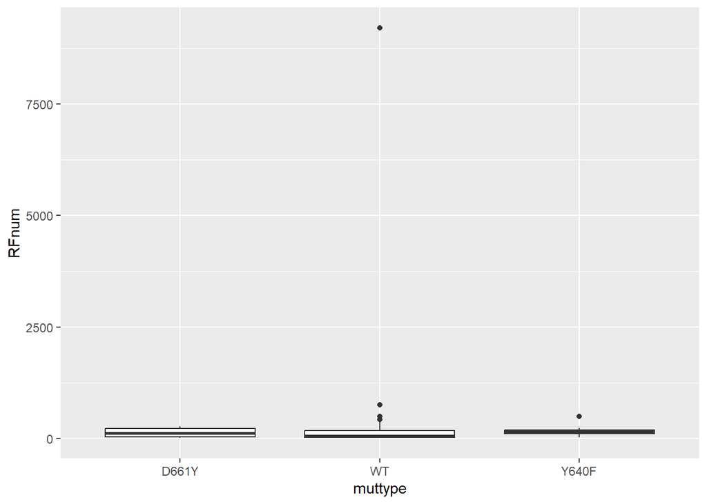

```r
RA3 %>% ggplot(aes(muttype, RFnum))+geom_boxplot()
```

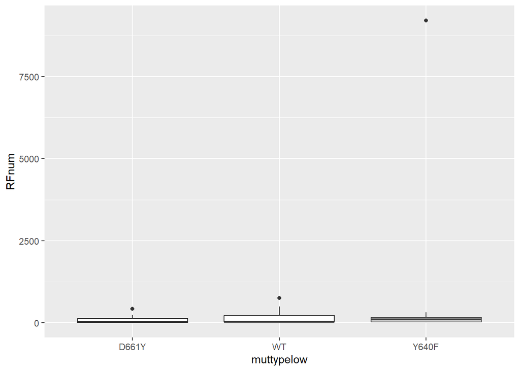

```r
RA4 %>% ggplot(aes(muttypelow, RFnum))+geom_boxplot()
```

```r
#there are no zeros, so can log transform
RA3 %>%
  arrange(RFnumna) %>%
  select(muttype, RFnumna)
```

```
## # A tibble: 96 × 2
##    muttype RFnumna
##    <chr>     <dbl>
##  1 D661Y       7
##  2 WT          7.1
##  3 WT          8.3
##  4 WT          8.9
##  5 WT          9.1
##  6 WT          9.6
##  7 WT         10
##  8 WT         10
##  9 WT         10.5
## 10 WT         13
## # ℹ 86 more rows
```

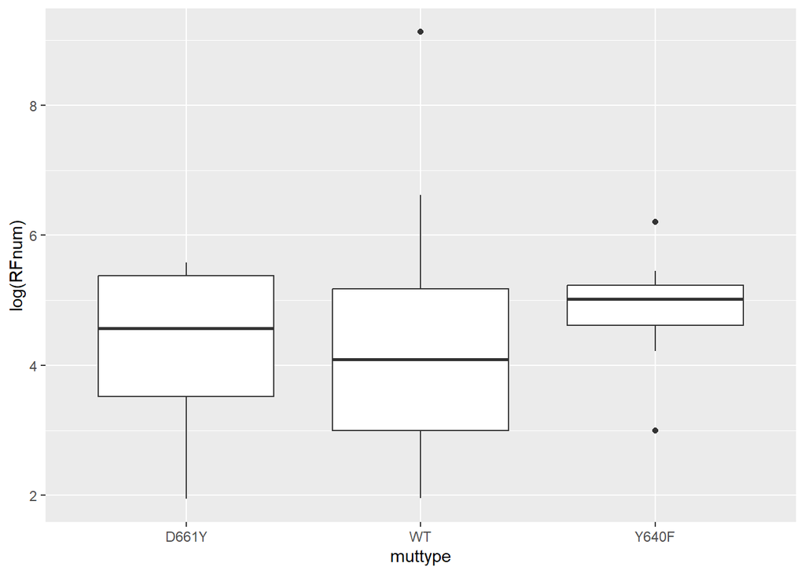

```r
RA3 %>% ggplot(aes(muttype, log(RFnum)))+geom_boxplot()
```

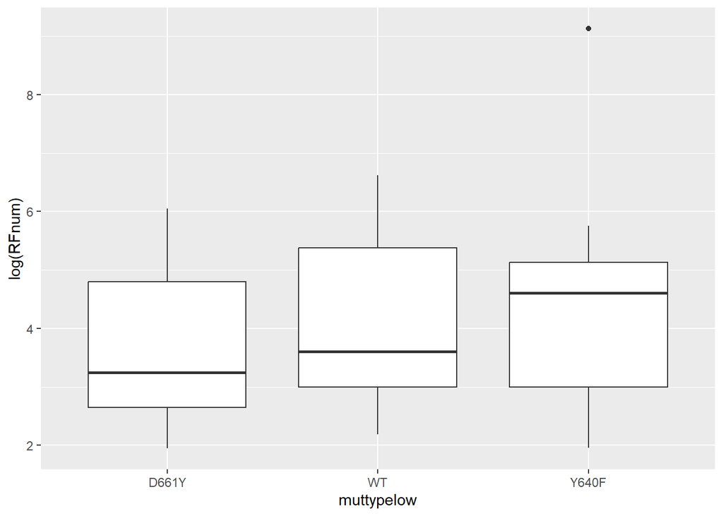

```r
RA4 %>% ggplot(aes(muttypelow, log(RFnum)))+geom_boxplot()
```

Run anova in order to test assumptions getting error in first line of this

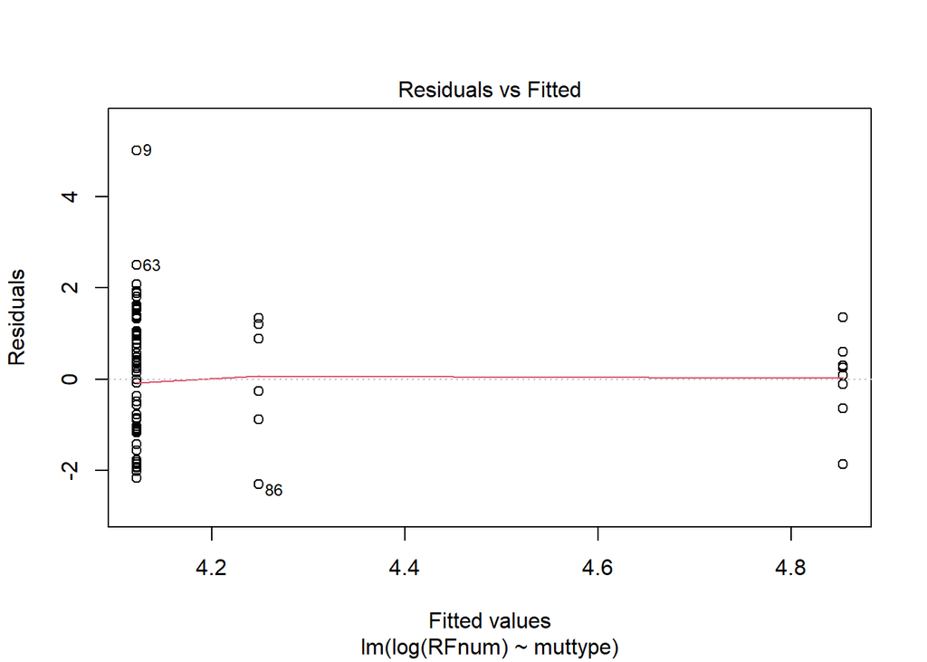

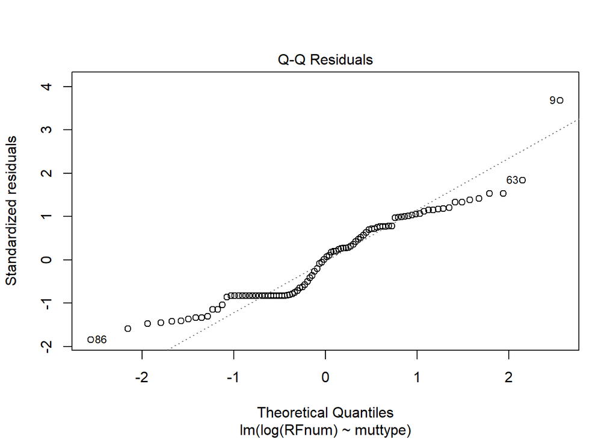

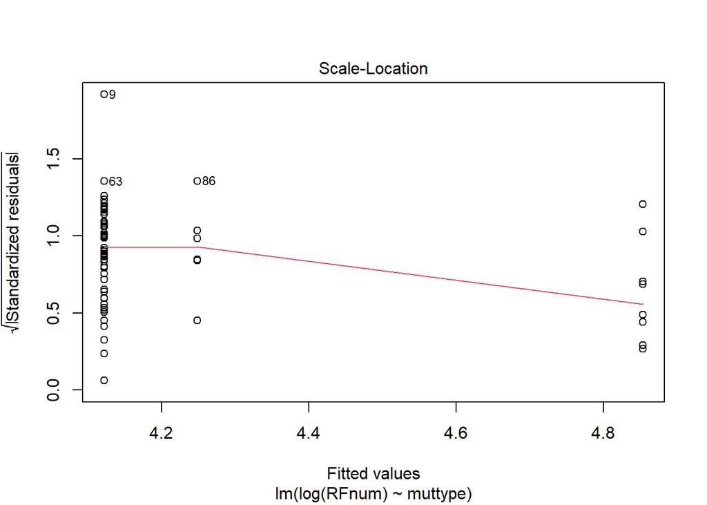

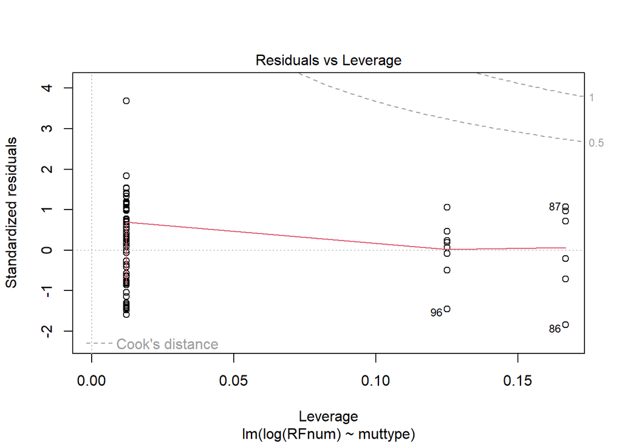

```r
modccp <- lm(log(RFnum)~muttype, data = RA3)
plot(modccp)
```

normality is really bad, so kruskal

```r
RA3 %>% kruskal_test(log(RFnum)~muttype)
```

```
## # A tibble: 1 × 6
##   .y.            n statistic    df     p method
## * <chr>      <int>     <dbl> <int> <dbl> <chr>
## 1 log(RFnum)    96      1.97     2 0.374 Kruskal-Wallis
```

```r
RA4 %>% kruskal_test(log(RFnum)~muttypelow)
```

```
## # A tibble: 1 × 6
##   .y.            n statistic    df     p method
## * <chr>      <int>     <dbl> <int> <dbl> <chr>
## 1 log(RFnum)    84     0.890     2 0.641 Kruskal-Wallis
```

```r
#making a data set
kruskal <-
  RA3 %>% kruskal_test(RFnum~muttype) %>%
  rbind(kruskal)

kruskal008 <-
  RA4 %>% kruskal_test(RFnum~muttypelow) %>%
  rbind(kruskal008)
```

### CRP anova

Make a box plot

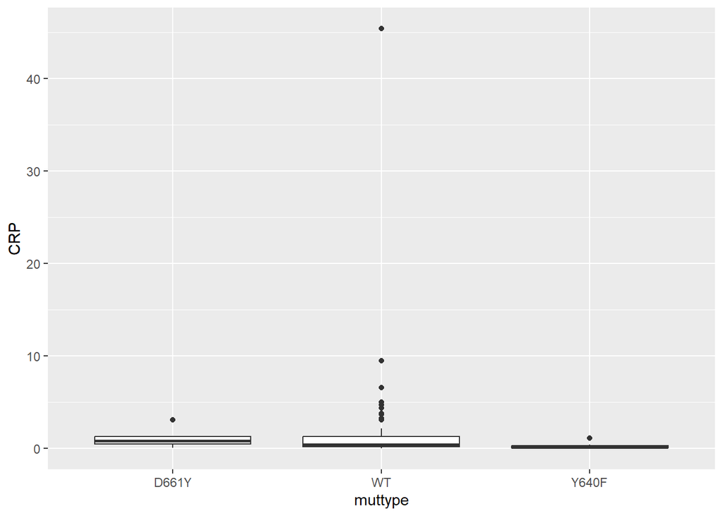

```r
RA3 %>% ggplot(aes(muttype, CRP))+geom_boxplot()
```

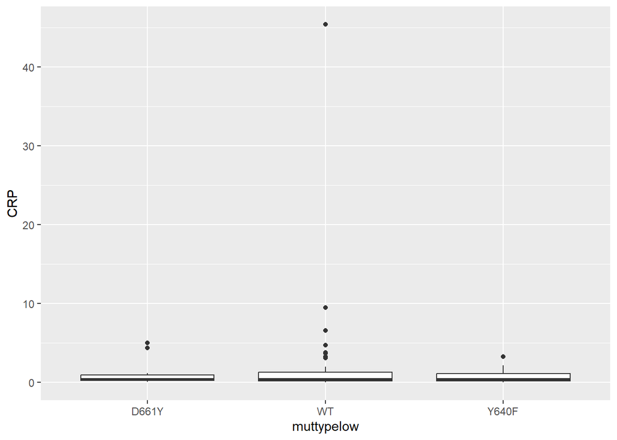

```r
RA4 %>% ggplot(aes(muttypelow, CRP))+geom_boxplot()
```

```r
#there are zeros, so can't log transform
RA3 %>%
  arrange(CRP) %>%
  select(muttype, CRP)
```

```
## # A tibble: 96 × 2
##    muttype   CRP
##    <chr>   <dbl>
##  1 WT        0
##  2 WT        0
##  3 WT        0
##  4 WT        0
##  5 Y640F     0
##  6 WT        0.1
##  7 WT        0.1
##  8 WT        0.1
##  9 WT        0.1
## 10 WT        0.1
## # ℹ 86 more rows
```

Run anova in order to test assumptions getting error in first line of this

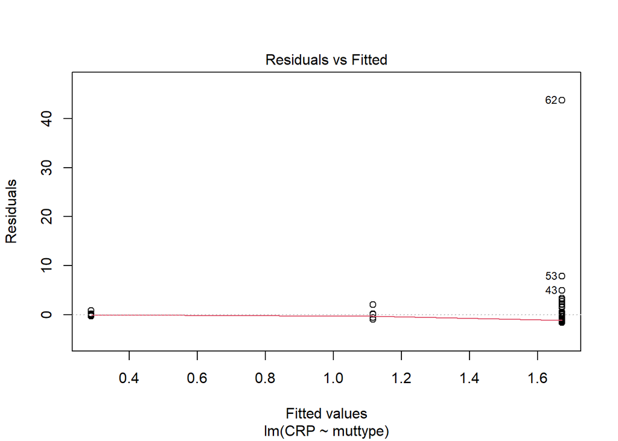

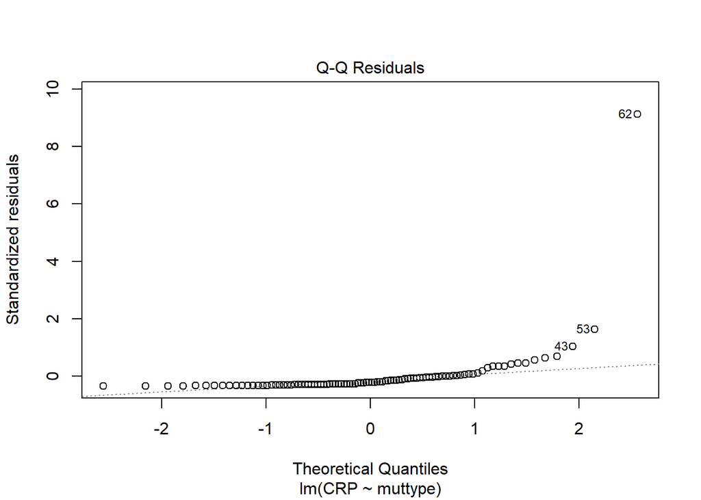

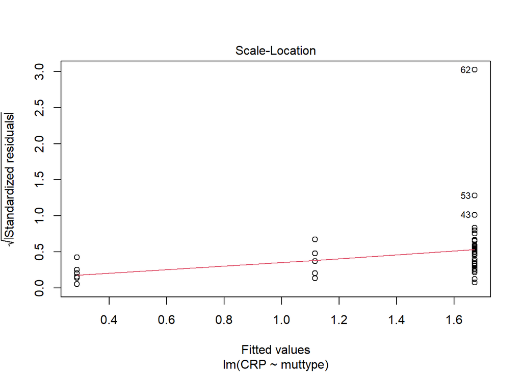

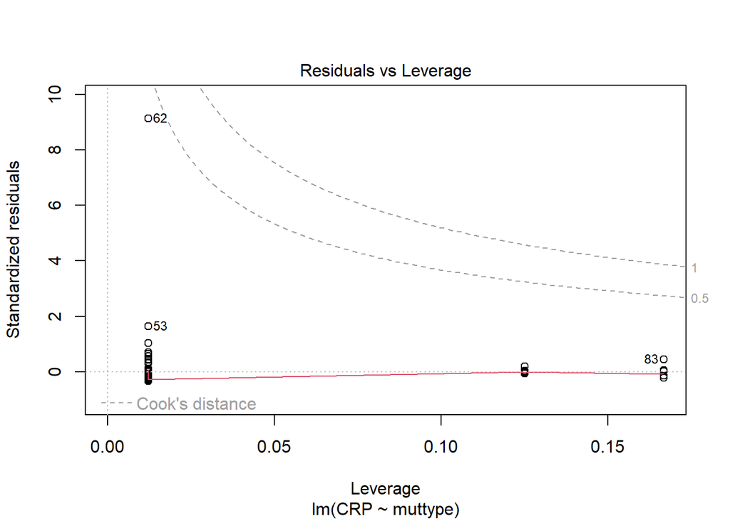

```r
modcrp <- lm(CRP~muttype, data = RA3)
plot(modcrp)
```

nonequal variance, so welch’s anova

```r
RA3 %>% welch_anova_test(CRP~muttype)
```

```
## # A tibble: 1 × 7
##   .y.       n statistic   DFn   DFd     p method
## * <chr> <int>     <dbl> <dbl> <dbl> <dbl> <chr>
## 1 CRP      96      4.05     2  14.4  0.04 Welch ANOVA
```

```r
RA4 %>% welch_anova_test(CRP~muttypelow)
```

```
## # A tibble: 1 × 7
##   .y.       n statistic   DFn   DFd     p method
## * <chr> <int>     <dbl> <dbl> <dbl> <dbl> <chr>
## 1 CRP      84      1.29     2  25.0 0.292 Welch ANOVA
```

```r
#making a data set
welch <-
  RA3 %>% welch_anova_test(CRP~muttype) %>%
  rbind(welch)

welch008 <-
  RA4 %>% welch_anova_test(CRP~muttypelow) %>%
  rbind(welch008)
```

tried kruskal because the welch was unexpectedly significant, and neither condition is well met

```r
RA3 %>% kruskal_test(CRP~muttype)
```

```
## # A tibble: 1 × 6
##   .y.       n statistic    df      p method
## * <chr> <int>     <dbl> <int>  <dbl> <chr>
## 1 CRP      96      5.73     2 0.0569 Kruskal-Wallis
```

```r
RA4 %>% kruskal_test(CRP~muttypelow)
```

```
## # A tibble: 1 × 6
##   .y.       n statistic    df     p method
## * <chr> <int>     <dbl> <int> <dbl> <chr>
## 1 CRP      84     0.419     2 0.811 Kruskal-Wallis
```

post hoc testing to see where the difference is coming from -shows that it is from wt to y640f comparison, but on their own, none are significant

```r
games_howell_test(RA3, formula = CRP~muttype)
```

```
## # A tibble: 3 × 8
##   .y.   group1 group2 estimate conf.low conf.high p.adj p.adj.signif
## * <chr> <chr>  <chr>     <dbl>    <dbl>     <dbl> <dbl> <chr>
## 1 CRP   D661Y  WT        0.555    -1.21   2.32    0.722 ns
## 2 CRP   D661Y  Y640F    -0.829    -2.24   0.583   0.244 ns
## 3 CRP   WT     Y640F    -1.38     -2.77   0.00401 0.051 ns
```

trying welch’s t test on mut instead of muttype after seeing difference in both statistical tests

```r
t.test(CRP~muts, data = RA3)
```

```
##
##  Welch Two Sample t-test
##
## data:  CRP by muts
## t = 1.819, df = 5.8123, p-value = 0.1204
## alternative hypothesis: true difference in means between group D661Y and group Y640F is not equal to 0
## 95 percent confidence interval:
##  -0.2950242  1.9533576
## sample estimates:
## mean in group D661Y mean in group Y640F
##            1.116667            0.287500
```

```r
t.test(CRP~muts008, data = RA4)
```

```
##
##  Welch Two Sample t-test
##
## data:  CRP by muts008
## t = 0.84723, df = 11.749, p-value = 0.4138
## alternative hypothesis: true difference in means between group D661Y and group Y640F is not equal to 0
## 95 percent confidence interval:
##  -0.7389657  1.6756661
## sample estimates:
## mean in group D661Y mean in group Y640F
##           1.2090909           0.7407407
```

###ESR anova